# RF_DDA

##### 4.3.11 Target Variable(Credit_Score ) with Payment_of_Min_Amount Column

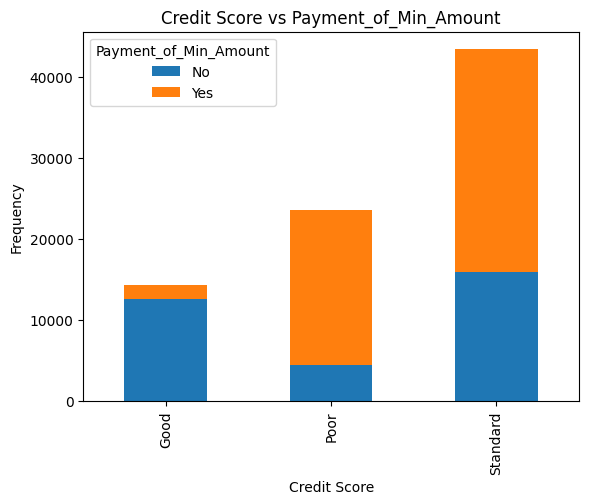

```python
# Create the contingency table
table = pd.crosstab(Clean_dataset['Credit_Score'], Clean_dataset['Payment_of_Min_Amount'])

# Plot the table
table.plot(kind='bar', stacked=True)
plt.title('Credit Score vs Payment_of_Min_Amount')
plt.xlabel('Credit Score')
plt.ylabel('Frequency')
plt.show()
```

**Observation**

- For good credit score the payment of min amount value as NO is very high while in case of standard and poor credit score the payment of min value as YES is high.

##### 4.3.12 Target Variable(Credit_Score ) with Payment_Behaviour Column

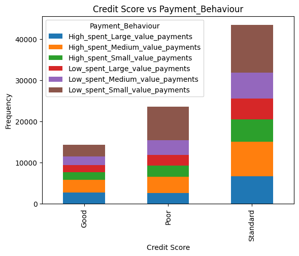

```python
# Create the contingency table
table = pd.crosstab(Clean_dataset['Credit_Score'], Clean_dataset['Payment_Behaviour'])

# Plot the table
table.plot(kind='bar', stacked=True)
plt.title('Credit Score vs Payment_Behaviour')
plt.xlabel('Credit Score')
plt.ylabel('Frequency')
plt.show()
```

**Observation**

- The distribution of payment behavior with respect to credit score is shown where low spent small value as a large share in standard credit score.

**Observation**

##### 4.3.13 Coorelation Matrix of all numeric variables Column

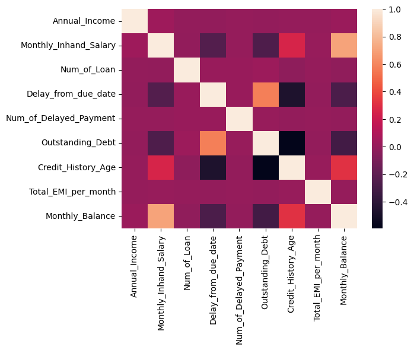

```python
Numeric_columns = ['Annual_Income', 'Monthly_Inhand_Salary', 'Num_of_Loan', 'Delay_from_due_date', 'Num_of_Delayed_Payment', 'Outstanding_Debt', 'Credit_History_Age', 'Total_EMI_per_month',
       'Monthly_Balance']
heatmap_data = Clean_dataset[Numeric_columns].copy()
sns.heatmap(heatmap_data.corr())
```

**Observation**

- Correlation of different numeric values is seen in the above matrix and it can be seen that Monthly balance and monthly inhand salary are highly correlated.

#### 4.4 Dealing with Outliers

##### 4.4.1 Dealing with the Num_of_Loan column

```python
Clean_dataset['Num_of_Loan'].value_counts()
```

```
3.0      12251
2.0      12220
0.0      12073
4.0      11968
1.0       8619
         ...
241.0        1
630.0        1
252.0        1
745.0        1
966.0        1
Name: Num_of_Loan, Length: 340, dtype: int64
```

**Observation**

- We have identified the Num_Of_Loan has Outliers, where Num_Of_Loan values greater than 9 the occurence is mostly 1.

```python
#Replacing the values of Num_Of_Loan values with 'NAN' wherever the Num_Of_Loan value is greater than 9
Clean_dataset.loc[Clean_dataset['Num_of_Loan'] > 9, 'Num_of_Loan'] = np.nan
```

```python
# Calculate the median Num_of_Loan by customer using groupby and summarize
median_Num_of_Loan_customer = Clean_dataset.groupby('Customer_ID').agg(median_Num_of_Loan=('Num_of_Loan', 'median'))

# Join the median Num_of_Loan column to the dataset
Clean_dataset = pd.merge(Clean_dataset, median_Num_of_Loan_customer, on='Customer_ID', how='left')

# Replace rows with a value of 0 in Num_of_Loan column with median Num_of_Loan
Clean_dataset['Num_of_Loan'].fillna(Clean_dataset['median_Num_of_Loan'], inplace=True)

# Drop the median Num_of_Loan column
Clean_dataset.drop('median_Num_of_Loan', axis=1, inplace=True)
```

```python
Clean_dataset['Num_of_Loan'].value_counts()
```

```
3.0    12304
2.0    12271
0.0    12121
4.0    12049
1.0     8670
6.0     6372
5.0     5951
7.0     5937
9.0     3018
8.0     2591
Name: Num_of_Loan, dtype: int64
```

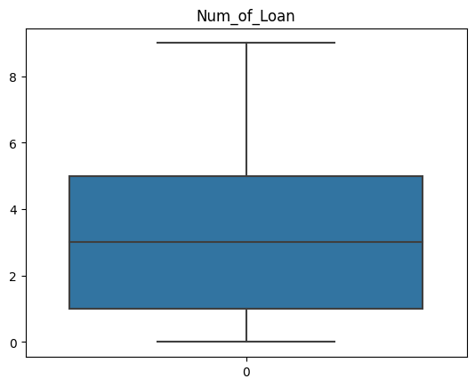

```python
fig, box = plt.subplots()
plt.title('Num_of_Loan')
sns.boxplot(Clean_dataset['Num_of_Loan'], ax=box)
```

**Outcome**

- We replaced the values greater than 9 with NAN.
- Further we imputed NAN values with median value.
- Finally the boxplot clears that there are no more outliers.

##### 4.4.2 Dealing with the Num_of_Delayed_Payment column

```python
Clean_dataset['Num_of_Delayed_Payment'].value_counts()
```

```
19.0      4752
17.0      4682
16.0      4648
18.0      4619
10.0      4612
          ...
1869.0       1
1685.0       1
2243.0       1
49.0         1
2047.0       1
Name: Num_of_Delayed_Payment, Length: 618, dtype: int64
```

**Observation**

- We have identified the Num_of_Delayed_Payment has Outliers, where Num_of_Delayed_Payment values are greater than 28 the occurence is mostly 1.

```python
#Replacing Num_of_Delayed_payment grater than 28 with nan
Clean_dataset.loc[Clean_dataset['Num_of_Delayed_Payment'] > 28, 'Num_of_Delayed_Payment'] = np.nan
```

```python
# Calculate the median Num_of_Delayed_Payment by customer using groupby and summarize
median_Num_of_Delayed_Payment_customer = Clean_dataset.groupby('Customer_ID').agg(median_Num_of_Delayed_Payment=('Num_of_Delayed_Payment', 'median'))

# Join the median Num_of_Delayed_Payment column to the dataset
Clean_dataset = pd.merge(Clean_dataset, median_Num_of_Delayed_Payment_customer, on='Customer_ID', how='left')

# Replace rows with a value of 0 in Num_of_Delayed_Payment column with median Num_of_Delayed_payment
Clean_dataset['Num_of_Delayed_Payment'].fillna(Clean_dataset['median_Num_of_Delayed_Payment'], inplace=True)

# Drop the median Num_of_Delayed_Payment column
Clean_dataset.drop('median_Num_of_Delayed_Payment', axis=1, inplace=True)
```

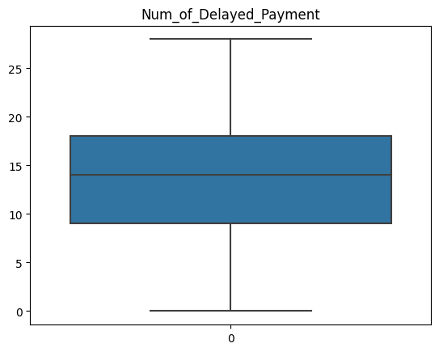

```python
fig, box = plt.subplots()
plt.title('Num_of_Delayed_Payment')
sns.boxplot(Clean_dataset['Num_of_Delayed_Payment'], ax=box)
```

**Outcome**

- We replaced the values greater than 28 with NAN.
- Further we imputed NAN values with median value.
- Finally the boxplot clears that there are no more outliers.

#### 4.5 Downloading the Clean_dataset before further processing

```python
# write the DataFrame to a CSV file
Clean_dataset.to_csv('Clean_dataset.csv', index=False)
```

```python
# download the CSV file to your local system
from google.colab import files
files.download('Clean_dataset.csv')
```

```python
Clean_dataset.shape
```

```
(81284, 15)
```

#### 4.6 Feature Extraction

##### 4.6.1 Occupation Column converted to Numeric using One Hot Encoding

```python
#create dummy variables for the Occupation column
dummy_occupation = pd.get_dummies(Clean_dataset['Occupation'],drop_first = True)
```

```python
#concatenate with the main final_dataset and store in it.
encoded_dataset = pd.concat([dummy_occupation, Clean_dataset, ],axis = 1)
```

```python
#drop the original Occupation column
encoded_dataset.drop('Occupation', axis=1 , inplace=True)
```

**Outcome**

##### 4.6.2 Payment_of_Min_Amount Column converted to Numeric using Ordinal Encoding

```python
Clean_dataset['Payment_of_Min_Amount'].value_counts()
```

```
Yes    48320
No     32964
Name: Payment_of_Min_Amount, dtype: int64
```

```python
# Creating the min_amount_category feature with the values of Payment_of_Min_Amount and encoded the same with Ordinal Encoding Technique
min_amount_category = ['Yes',
               'No']
encoder = OrdinalEncoder(categories=[min_amount_category])
encoded_dataset['Payment_of_Min_Amount'] = encoder.fit_transform(Clean_dataset[['Payment_of_Min_Amount']])
```

```python
encoded_dataset['Payment_of_Min_Amount'].value_counts()
```

```
0.0    48320
1.0    32964
Name: Payment_of_Min_Amount, dtype: int64
```

**Outcome**

##### 4.6.3 Payment_Behaviour Column converted to Numeric using Ordinal Encoding

```python
Clean_dataset['Payment_Behaviour'].value_counts()
```

```
Low_spent_Small_value_payments      22489
High_spent_Medium_value_payments    15379
Low_spent_Medium_value_payments     12132
High_spent_Large_value_payments     12102
High_spent_Small_value_payments      9961
Low_spent_Large_value_payments       9221
Name: Payment_Behaviour, dtype: int64
```

```python
# Creating the Categories feature with the values of Payment_Behaviour
payment_behaviour_categories = ['Low_spent_Small_value_payments',
              'Low_spent_Medium_value_payments',
              'Low_spent_Large_value_payments',
              'High_spent_Small_value_payments',
              'High_spent_Medium_value_payments',
              'High_spent_Large_value_payments'
              ]

# Creating the Encoder with the features "Categories" created above
encoder = OrdinalEncoder(categories=[payment_behaviour_categories])

# Performing Ordinal Encoding for the Payment_Behaviour COlumn and creating a New column called Payment_Behaviour_Encoded
encoded_dataset['Payment_Behaviour'] = encoder.fit_transform(Clean_dataset[['Payment_Behaviour']])
```

```python
encoded_dataset['Payment_Behaviour'].value_counts()
```

```
0.0    22489
4.0    15379
1.0    12132
5.0    12102
3.0     9961
2.0     9221
Name: Payment_Behaviour, dtype: int64
```

**Outcome**

- We identified that Payment_Behaviour column has ordinal Values.
- For the Modeling aspects we are converting this Ordinal Categorical Varible to Numerical Value using the Ordinal Encoding technique.
- Based on this Technique we converted:
- Low_spent_Small_value_payments to **0**
- Low_spent_Medium_value_payments to **1**
- Low_spent_Large_value_payments to **2**
- High_spent_Small_value_payments to **3**
- High_spent_Medium_value_payments to **4**
- High_spent_Large_value_payments to **5**

##### 4.6.4 Credit_Score Column [Target Variable] converted to Numeric using Ordinal Encoding

```python
Clean_dataset['Credit_Score'].value_counts()
```

```
Standard    43401
Poor        23532
Good        14351
Name: Credit_Score, dtype: int64
```

```python
# Creating the Categories feature with the values of Payment_Behaviour
credit_score_categories = ["Poor","Standard","Good"]

# Creating the Encoder with the features "Categories" created above
encoder = OrdinalEncoder(categories=[credit_score_categories])

# Performing Ordinal Encoding for the Payment_Behaviour COlumn and creating a New column called Payment_Behaviour_Encoded
encoded_dataset['Credit_Score'] = encoder.fit_transform(Clean_dataset[['Credit_Score']])

# Converting the Credit_Score column as int
encoded_dataset["Credit_Score"] = encoded_dataset['Credit_Score'].astype(int)
```

```python
encoded_dataset['Credit_Score'].value_counts()
```

```
1    43401
0    23532
2    14351
Name: Credit_Score, dtype: int64
```

**Outcome**

- We identified that Credit_Score column has ordinal Values.
- For the Modeling aspects we are converting this Ordinal Categorical Varible to Numerical Value using the Ordinal Encoding technique.
- Based on this Technique we converted:
- Poor to **0**
- Standard to **1**
- Good to **2**

```python
# Creating the encoded_dataset for the Model and dropping the columns which are not required
encoded_dataset = encoded_dataset.drop(["ID", "Customer_ID"], axis=1)
```

#### 4.7 Encoded Dataset

```python
# write the DataFrame to a CSV file
encoded_dataset.to_csv('encoded_dataset.csv', index=False)
```

```python
# download the CSV file to your local system
from google.colab import files
files.download('encoded_dataset.csv')
```

### 5. Making Training & Testing dataset for imbalanced data

```python
# read the CSV file and load it into a DataFrame object
imbalanced_dataset = pd.read_csv('encoded_dataset.csv')
```

```python
#Splitting the imbalanced_dataset into Train and test Features and Targets

X = imbalanced_dataset.drop('Credit_Score', axis=1)
y = imbalanced_dataset[['Credit_Score']]
X_train, X_test, y_train, y_test = train_test_split(X, y, test_size=0.3, random_state=42)
```

```python
X.shape
```

```
(81284, 25)
```

**Observation**

- X_train/X_test = Features (excluding the Credit_Score)
- y_train/y_test = Target(Credit_Score)

```python
# Creating the imbalanced_dataset Train & Test data split for future Use
imbalanced_dataset_train = pd.concat([pd.DataFrame(X_train), pd.DataFrame(y_train)], axis = 1)
imbalanced_dataset_test = pd.concat([pd.DataFrame(X_test), pd.DataFrame(y_test)], axis = 1)
```

```python
#Exporting to CSV
imbalanced_dataset_train.to_csv('imbalanced_dataset_train.csv', index=False)
imbalanced_dataset_test.to_csv('imbalanced_dataset_test.csv', index=False)
```

**Outcome**

- The imbalanced dataset is splitted into train and test and has been stored in a csv file.

### 6. Balancing the Target variable [Credit_Score]

```python
# Count the number of occurrences of each unique value in the "Credit_Score" column
encoded_dataset.groupby('Credit_Score')['Credit_Score'].count()
```

```
Credit_Score
0    23532
1    43401
2    14351
Name: Credit_Score, dtype: int64
```

**Observation**

- The dataset has target variable imbalanced(unevenly distributed).
- To fix the above we will use **Synthetic Minority Oversampling Technique** **(SMOTE)** technique

```python
#Apply SMOTE on the training features(X) and target variable[Credit_Score](y)
smote = SMOTE()
X_train_resampled, y_train_resampled = smote.fit_resample(X_train, y_train)
```

#### 6.1 Making Balanced Training dataset and test dataset

```python
# Creating the imbalanced_dataset Train & Test data split for future Use
balanced_dataset_train = pd.concat([pd.DataFrame(X_train_resampled), pd.DataFrame(y_train_resampled)], axis = 1)
balanced_dataset_test = pd.concat([pd.DataFrame(X_test), pd.DataFrame(y_test)], axis = 1)
```

```python
#Exporting to CSV
balanced_dataset_train.to_csv('balanced_dataset_train.csv', index=False)
balanced_dataset_test.to_csv('balanced_dataset_test.csv', index=False)
```

**Outcome**

- The train dataset is balaced for the target variable.
- A new balanced dataset is formed for both train and test for further ML modelling.

### 7. Feature Scaling

```python
#Since there were extreme Values in the Data standardizing the Values
scaler = StandardScaler()

#standardizing the data using the Scaler
#fit transformation on the Training Data
X_train_scaled = scaler.fit_transform(X_train_resampled)

#transform the test set using the same transformation as the training set
X_test_scaled = scaler.transform(X_test)
```

**Outcome**

- The X_train_resampled (training features) and X_test(test features) are scaled.
- This will ensure that all features are on the same scale and have equal importance, which helps to improve the performance of PCA.

### 8. Implimenting Principal Component Analysis [PCA]

```python
# Specifies the amount of variance that the PCA should preserve in the transformed data
pca = PCA(0.85)
```

```python
# Dimentionality reduction on features of train and test dataset
PCA_X_train = pca.fit_transform(X_train_scaled)
PCA_X_test = pca.transform(X_test_scaled)
```

```python
# Checking the number of features left after reduction
PCA_X_train.shape
```

```
(91251, 17)
```

```python
# Convert the PCA_X_test(numpy array) to pandas dataframe
PCA_X_test_dataframe = pd.DataFrame(PCA_X_test)

# The index is reset for y_test Pandas DataFrame
y_test.reset_index(drop=True, inplace=True)
```

**Outcome**

- We implemented PCA by specifying the amount of variance which should be preserved **(85%)**.
- This technique preserves most of the important information in the original data.
- The reduction after applying PCA is **17** from **25**.
- The PCA_X_test is converted to a pandas dataframe and y_test indexes are reset so that these can be merged to form a test dataset.

#### 8.1 PCA implemented Dataset

```python
# Creating the pca_dataset Train & Test data split for future Use
pca_dataset_train = pd.concat([pd.DataFrame(PCA_X_train), pd.DataFrame(y_train_resampled)], axis = 1)
pca_dataset_test = pd.concat([pd.DataFrame(PCA_X_test_dataframe), pd.DataFrame(y_test)], axis = 1)
```

```python
#Exporting to CSV
pca_dataset_train.to_csv('pca_dataset_train.csv', index=False)
pca_dataset_test.to_csv('pca_dataset_test.csv', index=False)
```

**Outcome**

- A new pca dataset is formed for both train and test for further ML modelling.

### 9. Implimenting KMean Clustering

#### 9.1 Load the dataset and split it into Feature and Target

```python
# Load the pca_dataset_train dataset from CSV file
pca_train_dataset = pd.read_csv('pca_dataset_train.csv')

# Load the pca_dataset_test dataset from CSV file
pca_test_dataset = pd.read_csv('pca_dataset_test.csv')
```

```python
# Extract the features and target variable from the train dataset
pca_X_train = pca_train_dataset.drop('Credit_Score', axis=1)
pca_y_train = pca_train_dataset['Credit_Score']
```

```python
# Extract the features and target variable from the train dataset
pca_X_test = pca_test_dataset.drop('Credit_Score', axis=1)
pca_y_test = pca_test_dataset['Credit_Score']
```

#### 9.2 Applying KMeans to pca_X_train

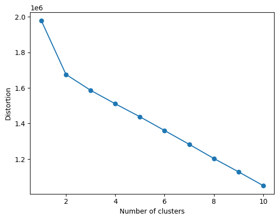

```python
# Find the optimal number of clusters using the elbow method
distortions = []
for i in range(1, 11):
    kmeans = KMeans(n_clusters=i, random_state=0)
    kmeans.fit(pca_X_train)
    distortions.append(kmeans.inertia_)

# Plot the elbow curve
import matplotlib.pyplot as plt
plt.plot(range(1, 11), distortions, marker='o')
plt.xlabel('Number of clusters')
plt.ylabel('Distortion')
plt.show()
```

**Observation**

```python
# From the elbow curve, select the optimal number of clusters
k = 3

# Apply K-Means clustering on the training dataset
kmeans = KMeans(n_clusters=k, random_state=0)
kmeans.fit(pca_X_train)
train_cluster_labels = kmeans.labels_
centroids = kmeans.cluster_centers_

# Add the cluster labels as additional features to the training dataset
pca_X_train['cluster_label'] = train_cluster_labels

# Apply K-Means clustering on the testing dataset
test_cluster_labels = kmeans.predict(pca_X_test)

# Add the cluster labels as additional features to the testing dataset
pca_X_test['cluster_label'] = test_cluster_labels

# Calculate the silhouette score for the training dataset
silhouette_avg = silhouette_score(pca_X_train, train_cluster_labels)
print(f"Silhouette score for {k} clusters: {silhouette_avg}")
```

```
Silhouette score for 3 clusters: 0.1473141683094037
```

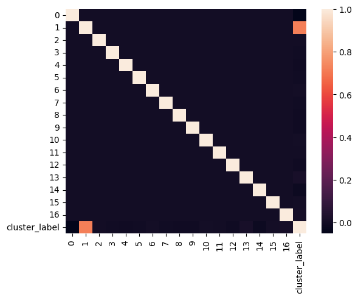

```python
data = pca_X_train

# Compute correlation matrix
corr_matrix = data.corr()

# Visualize correlation matrix

sns.heatmap(corr_matrix)
```

Outcome:

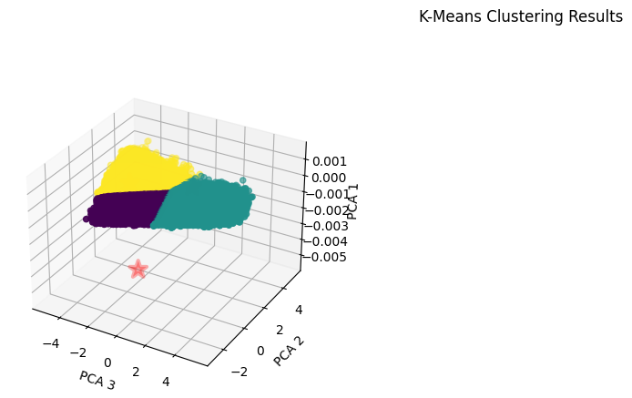

```python
from matplotlib import markers
import matplotlib.pyplot as plt
from mpl_toolkits.mplot3d import Axes3D

# Create subplots for PC1 vs PC2, PC1 vs PC3, and PC2 vs PC3
fig = plt.figure(figsize=(15,5))

ax1 = fig.add_subplot(131, projection='3d')
ax1.scatter(pca_X_train['0'], pca_X_train['1'], c=train_cluster_labels)
ax1.scatter(centroids[:, 0], centroids[:, 1], centroids[:, 2], marker='*', s=200, linewidths=3, color='r')
ax1.set_xlabel('PCA 3')
ax1.set_ylabel('PCA 2')
ax1.set_zlabel('PCA 1')


plt.suptitle('K-Means Clustering Results')
#plt.legend(title='Cluster', labels=['0','1','2'])
plt.show()
```

```python
pca_X_train.groupby('cluster_label')['cluster_label'].count()
```

```
cluster_label
0    38024
1    34122
2    19105
Name: cluster_label, dtype: int64
```

#### 9.3 KMeans implemented Dataset

```python
# Creating the cluster_dataset Train & Test data split for future Use
cluster_dataset_train = pd.concat([pd.DataFrame(pca_X_train), pd.DataFrame(pca_y_train)], axis = 1)
cluster_dataset_test = pd.concat([pd.DataFrame(pca_X_test), pd.DataFrame(pca_y_test)], axis = 1)
```

```python
#Exporting to CSV
cluster_dataset_train.to_csv('cluster_dataset_train.csv', index=False)
cluster_dataset_test.to_csv('cluster_dataset_test.csv', index=False)
```

**Observation**

- Three clusters are formed with cluster lables 0,1 and 2.
- 0 and 1 have more portion of point while 2 has just 19105 points.

### 10. Supervised Learning Implementation using Python in PySpark

#### 10.1 Creating Spark Session

```python
spark=SparkSession.builder.master("local[*]").appName("New").getOrCreate()
sc=spark.sparkContext
```

**Outcome**

- The new spark session is created and context is set for its use.
- The session is set with the app name as "New".

#### 10.2 Applying Random Forest on Balanced Dataset

##### 10.2.1 Loading Dataset

```python
# Import Train and Test Dataset
balanced_train_dataset = spark.read.csv('./balanced_dataset_train.csv', header=True, inferSchema=True)
balanced_test_dataset = spark.read.csv('./balanced_dataset_test.csv', header=True, inferSchema=True)
```

##### 10.2.2 Modelling the dataset with Random Forest Classifier

```python
# Define the input features and target column name
feature_cols = balanced_train_dataset.columns[:-1]
target_col = 'Credit_Score'
```

```python
# Create a VectorAssembler to combine the input features into a vector
assembler = VectorAssembler(inputCols=feature_cols, outputCol='features')
```

```python
# Transform the dataset
train_dataset_balance = assembler.transform(balanced_train_dataset).select("features", "Credit_Score")
test_dataset_balance = assembler.transform(balanced_test_dataset).select("features", "Credit_Score")
```

```python
# Define the Random Forest Classifier model with appropriate parameters
rf = RandomForestClassifier(labelCol=target_col, featuresCol="features", numTrees=100, maxDepth=10,seed=42)
```

```python
# Fit the model to the training data
model = rf.fit(train_dataset_balance)
```

##### 10.2.3 Predecting the model on the test dataset

```python
# Make predictions on the test data
predictions = model.transform(test_dataset_balance)
```

```python
# Evaluate the model's performance using the MulticlassClassificationEvaluator
evaluator = MulticlassClassificationEvaluator(labelCol=target_col, metricName="accuracy")
accuracy = evaluator.evaluate(predictions)
print("Test Accuracy is {:.3f} ".format(accuracy))
```

```
Test Accuracy is 0.632
```

##### 10.2.4 Performane evaluation of the model

- Precision: Precision measures the fraction of positive predictions that are correct.
- Recall: Recall measures the fraction of positive instances that are correctly predicted.
- F1 Score: F1 score is the harmonic mean of precision and recall.

```python
evaluator = MulticlassClassificationEvaluator(labelCol="Credit_Score", predictionCol="prediction", metricName="weightedPrecision")
precision = evaluator.evaluate(predictions)
evaluator = MulticlassClassificationEvaluator(labelCol="Credit_Score", predictionCol="prediction", metricName="weightedRecall")
recall = evaluator.evaluate(predictions)
evaluator = MulticlassClassificationEvaluator(labelCol="Credit_Score", predictionCol="prediction", metricName="f1")
f1 = evaluator.evaluate(predictions)

print("Precision: {:.3f}".format(precision))
print("Recall: {:.3f}".format(recall))
print("F1 score: {:.3f}".format(f1))
```

```
Precision: 0.696
Recall: 0.632
F1 score: 0.631
```

```
Confusion Matrix:
[[5672. 3351.  161.]
 [ 717. 6380.  696.]
 [ 796. 3253. 3360.]]
```

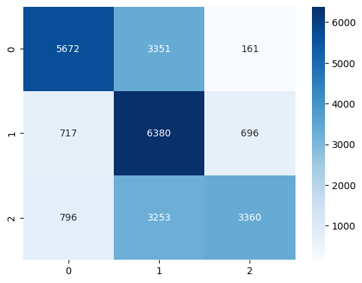

```python
# Convert labels to DoubleType
predictions = predictions.select(col("Credit_Score").cast("double").alias("Credit_Score"), "prediction")

# Calculate the confusion matrix
metrics = MulticlassMetrics(predictions.rdd.map(tuple))

# Print the confusion matrix
print("Confusion Matrix:")
print(metrics.confusionMatrix().toArray())

# Create a heatmap of the confusion matrix
sns.heatmap(metrics.confusionMatrix().toArray(), annot=True, cmap="Blues", fmt="g")
```

**Observation**

- The Accuracy of a balanced dataset is 0.632 when the number of trees are 100 and maximum depth is 10.

#### 10.3 Applying Random Forest on balanced PCA implemented Dataset

##### 10.3.1 Loading Dataset

```python
# Import Train and Test Dataset
pca_train_dataset = spark.read.csv('./pca_dataset_train.csv', header=True, inferSchema=True)
pca_test_dataset = spark.read.csv('./pca_dataset_test.csv', header=True, inferSchema=True)
```

##### 10.3.2 Implementing Random Forest on the loaded dataset

```python
# Define the input features and target column name
feature_cols = pca_train_dataset.columns[:-1]
target_col = 'Credit_Score'
```

```python
# Create a VectorAssembler to combine the input features into a vector
assembler = VectorAssembler(inputCols=feature_cols, outputCol='features')
```

```python
# Transform the dataset
train_dataset_pca = assembler.transform(pca_train_dataset).select("features", "Credit_Score")
test_dataset_pca = assembler.transform(pca_test_dataset).select("features", "Credit_Score")
```

```python
# Define the Random Forest Classifier model with appropriate parameters
pca_rf = RandomForestClassifier(labelCol=target_col, featuresCol="features", numTrees=100, maxDepth=10,seed=42)
```

```python
# Fit the model to the training data
pca_model = pca_rf.fit(train_dataset_pca)
```

##### 10.3.3 Predecting the model on the test dataset

```python
# Make predictions on the test data
pca_predictions = pca_model.transform(test_dataset_pca)
```

```python
# Evaluate the model's performance using the MulticlassClassificationEvaluator
evaluator = MulticlassClassificationEvaluator(labelCol=target_col, metricName="accuracy")
pca_accuracy = evaluator.evaluate(pca_predictions)
print("Test Accuracy is {:.3f} ".format(pca_accuracy))
```

```
Test Accuracy is 0.587
```

##### 10.3.4 Performane evaluation of the model

- Precision: Precision measures the fraction of positive predictions that are correct.
- Recall: Recall measures the fraction of positive instances that are correctly predicted.
- F1 Score: F1 score is the harmonic mean of precision and recall.

```python
evaluator = MulticlassClassificationEvaluator(labelCol="Credit_Score", predictionCol="prediction", metricName="weightedPrecision")
precision = evaluator.evaluate(pca_predictions)
evaluator = MulticlassClassificationEvaluator(labelCol="Credit_Score", predictionCol="prediction", metricName="weightedRecall")
recall = evaluator.evaluate(pca_predictions)
evaluator = MulticlassClassificationEvaluator(labelCol="Credit_Score", predictionCol="prediction", metricName="f1")
f1 = evaluator.evaluate(pca_predictions)

print("Precision: {:.3f}".format(precision))
print("Recall: {:.3f}".format(recall))
print("F1 score: {:.3f}".format(f1))
```

```
Precision: 0.641
Recall: 0.587
F1 score: 0.589
```

```
Confusion Matrix:
[[5019. 3475.  134.]
 [1124. 6184.  970.]
 [1042. 3325. 3113.]]
```

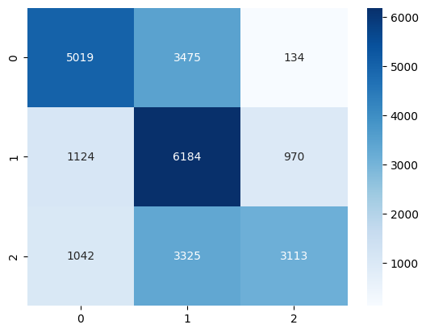

```python
# Convert labels to DoubleType
predictions = pca_predictions.select(col("Credit_Score").cast("double").alias("Credit_Score"), "prediction")

# Calculate the confusion matrix
metrics = MulticlassMetrics(predictions.rdd.map(tuple))

# Print the confusion matrix
print("Confusion Matrix:")
print(metrics.confusionMatrix().toArray())

# Create a heatmap of the confusion matrix
sns.heatmap(metrics.confusionMatrix().toArray(), annot=True, cmap="Blues", fmt="g")
```

**Observation**

- The Accuracy of a pca applied dataset is 0.587 when the number of trees are 100 and maximum depth is 10.

#### 10.4 Applying Random Forest on balanced cluster implemented Dataset

##### 10.4.1 Loading Dataset

```python
# Import Train and Test Dataset
cluster_train_dataset = spark.read.csv('./cluster_dataset_train.csv', header=True, inferSchema=True)
cluster_test_dataset = spark.read.csv('./cluster_dataset_test.csv', header=True, inferSchema=True)
```

##### 10.4.2 Implementing Random Forest on the loaded dataset

```python
# Define the input features and target column name
feature_cols = pca_train_dataset.columns[:-1]
target_col = 'Credit_Score'
```

```python
# Create a VectorAssembler to combine the input features into a vector
assembler = VectorAssembler(inputCols=feature_cols, outputCol='features')
```

```python
# Transform the dataset
train_dataset_cluster = assembler.transform(cluster_train_dataset).select("features", "Credit_Score")
test_dataset_cluster = assembler.transform(cluster_test_dataset).select("features", "Credit_Score")
```

```python
# Define the Random Forest Classifier model with appropriate parameters
cluster_rf = RandomForestClassifier(labelCol=target_col, featuresCol="features", numTrees=100, maxDepth=10,seed=42)
```

```python
# Fit the model to the training data
cluster_model = cluster_rf.fit(train_dataset_cluster)
```

##### 10.4.3 Predecting the model on the test dataset

```python
# Make predictions on the test data
cluster_predictions = cluster_model.transform(test_dataset_cluster)
```

```python
# Evaluate the model's performance using the MulticlassClassificationEvaluator
evaluator = MulticlassClassificationEvaluator(labelCol=target_col, metricName="accuracy")
cluster_accuracy = evaluator.evaluate(cluster_predictions)
print("Test Accuracy is {:.3f} ".format(cluster_accuracy))
```

```
Test Accuracy is 0.587
```

##### 10.4.4 Performane evaluation of the model

- Precision: Precision measures the fraction of positive predictions that are correct.
- Recall: Recall measures the fraction of positive instances that are correctly predicted.
- F1 Score: F1 score is the harmonic mean of precision and recall.

```python
evaluator = MulticlassClassificationEvaluator(labelCol="Credit_Score", predictionCol="prediction", metricName="weightedPrecision")
precision = evaluator.evaluate(cluster_predictions)
evaluator = MulticlassClassificationEvaluator(labelCol="Credit_Score", predictionCol="prediction", metricName="weightedRecall")
recall = evaluator.evaluate(cluster_predictions)
evaluator = MulticlassClassificationEvaluator(labelCol="Credit_Score", predictionCol="prediction", metricName="f1")
f1 = evaluator.evaluate(cluster_predictions)

print("Precision: {:.3f}".format(precision))
print("Recall: {:.3f}".format(recall))
print("F1 score: {:.3f}".format(f1))
```

```
Precision: 0.643
Recall: 0.587
F1 score: 0.589
```

```
Confusion Matrix:
[[5009. 3472.  134.]
 [1110. 6170.  940.]
 [1066. 3342. 3143.]]
```

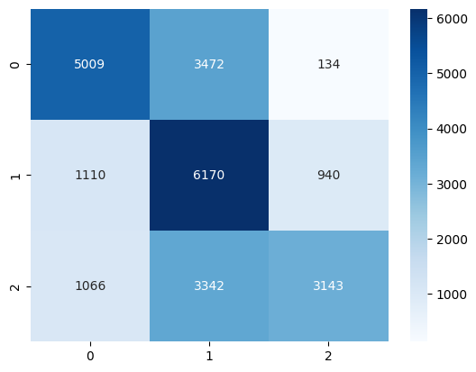

```python
# Convert labels to DoubleType
predictions = cluster_predictions.select(col("Credit_Score").cast("double").alias("Credit_Score"), "prediction")

# Calculate the confusion matrix
metrics = MulticlassMetrics(predictions.rdd.map(tuple))

# Print the confusion matrix
print("Confusion Matrix:")
print(metrics.confusionMatrix().toArray())

# Create a heatmap of the confusion matrix
sns.heatmap(metrics.confusionMatrix().toArray(), annot=True, cmap="Blues", fmt="g")
```

**Observation**

- The Accuracy of a K-Means clustering applied dataset is 0.587 when the number of trees are 100 and maximum depth is 10.

**Outcome**

- Based on the results of balanced dataset; PCA applied dataset; K-Means applied dataset it was noticed that balanced dataset has the best accuracy.
- Thus, Hyperparameter tunning is applied on this dataset for finding the best accuracy and parameters.

#### 10.5 Hyperparameter Tunning on best performing dataset

```python
# Import balanced Train and Test Dataset since it performed better than other datasets
hyper_train_dataset = spark.read.csv('./balanced_dataset_train.csv', header=True, inferSchema=True)
hyper_test_dataset = spark.read.csv('./balanced_dataset_test.csv', header=True, inferSchema=True)
```

```python
# Split the train dataset into train and validation set
train, validate = hyper_train_dataset.randomSplit([0.8, 0.2], seed=42)
```

```python
# Define the input columns to the vector assembler
inputCols = train.columns[:-1]  # all columns except the last one
```

```python
# Create a vector assembler object with the input columns
assembler = VectorAssembler(inputCols=inputCols, outputCol="features")
```

```python
# Transform the train, validate, and hyper_test_dataset with the vector assembler
train = assembler.transform(train).select("features", "Credit_Score")
validate = assembler.transform(validate).select("features", "Credit_Score")
hyper_test_dataset = assembler.transform(hyper_test_dataset).select("features", "Credit_Score")
```

```python
# Initialize the Random Forest Classifier
hyper_rf = RandomForestClassifier(labelCol='Credit_Score', seed=42)
```

```python
# Define the pipeline with RandomForestClassifier only
pipeline = Pipeline(stages=[hyper_rf])
```

```python
# Define the hyperparameter grid
param_grid = ParamGridBuilder() \
    .addGrid(hyper_rf.numTrees, [90,110]) \
    .addGrid(hyper_rf.maxDepth, [5, 15]) \
    .build()
```

```python
# Define the evaluator
evaluator = MulticlassClassificationEvaluator(labelCol='Credit_Score', metricName='accuracy')
```

```python
# Define the cross-validation object
crossval = CrossValidator(estimator=pipeline,
                          estimatorParamMaps=param_grid,
                          evaluator=evaluator,
                          numFolds=5,
                          seed=42)
```

```python
# Train the model using the training dataset
hyper_model = crossval.fit(train)
```

```python
# Make predictions on the validation dataset
predictions = hyper_model.transform(validate)
```

```python
# Evaluate the model on the validation dataset
accuracy = evaluator.evaluate(predictions)
print("Validation Accuracy = %g" % (accuracy))
```

```
Validation Accuracy = 0.753118
```

```python
# Make predictions on the test dataset
predictions = hyper_model.transform(hyper_test_dataset)
```

```python
# Evaluate the model on the test dataset
accuracy = evaluator.evaluate(predictions)
print("Test Accuracy = %g" % (accuracy))
```

```
Test Accuracy = 0.664603
```

```python
# Get the list of parameter maps and the average metrics
param_maps = hyper_model.getEstimatorParamMaps()
avg_metrics = hyper_model.avgMetrics
```

```python
# Get the index of the best parameter combination
best_index = avg_metrics.index(max(avg_metrics))
```

```python
# Get the best parameter combination and the corresponding accuracy
best_params = param_maps[best_index]
best_accuracy = avg_metrics[best_index]
```

```python
# Print the best parameter combination and the corresponding accuracy
print("Best parameters:", best_params)
print("Best accuracy:", best_accuracy)
```

[output not shown]

```python
# Get the best model with the optimal hyperparameters
best_model = hyper_model.bestModel
```

```python
# Make predictions on the test dataset using the best model
predictions = best_model.transform(hyper_test_dataset)
```

```python
# Evaluate the model on the test dataset
accuracy = evaluator.evaluate(predictions)
print("Test Accuracy = %g" % (accuracy))
```

```
Test Accuracy = 0.664603
```

##### 10.5.1 Performane evaluation of the model

- Precision: Precision measures the fraction of positive predictions that are correct.
- Recall: Recall measures the fraction of positive instances that are correctly predicted.
- F1 Score: F1 score is the harmonic mean of precision and recall.

```python
evaluator = MulticlassClassificationEvaluator(labelCol="Credit_Score", predictionCol="prediction", metricName="weightedPrecision")
precision = evaluator.evaluate(predictions)
evaluator = MulticlassClassificationEvaluator(labelCol="Credit_Score", predictionCol="prediction", metricName="weightedRecall")
recall = evaluator.evaluate(predictions)
evaluator = MulticlassClassificationEvaluator(labelCol="Credit_Score", predictionCol="prediction", metricName="f1")
f1 = evaluator.evaluate(predictions)

print("Precision: {:.3f}".format(precision))
print("Recall: {:.3f}".format(recall))
print("F1 score: {:.3f}".format(f1))
```

```
Precision: 0.711
Recall: 0.665
F1 score: 0.666
```

```
Confusion Matrix:
[[5680. 3031.  151.]
 [ 809. 7222.  761.]
 [ 696. 2731. 3305.]]
```

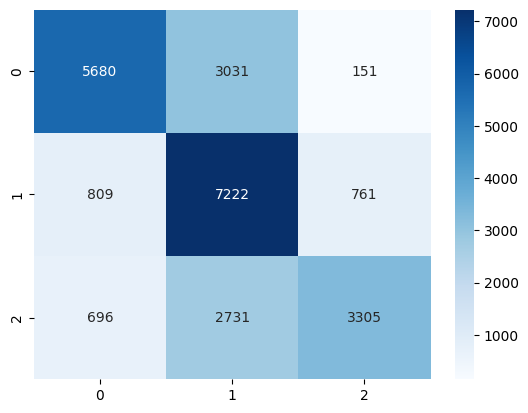

```python
# Convert labels to DoubleType
predictions = predictions.select(col("Credit_Score").cast("double").alias("Credit_Score"), "prediction")

# Calculate the confusion matrix
metrics = MulticlassMetrics(predictions.rdd.map(tuple))

# Print the confusion matrix
print("Confusion Matrix:")
print(metrics.confusionMatrix().toArray())

# Create a heatmap of the confusion matrix
sns.heatmap(metrics.confusionMatrix().toArray(), annot=True, cmap="Blues", fmt="g")
```

**Final Outcome**

Thus this is the best model which give the most accurate results for the credit score.